# Reto 1: ¿Cuántas ardillas rojas hay en Cali?

## Contexto

En Santiago de Cali habita una pequeña criatura que aporta encanto y vitalidad al entorno natural: la ardilla común (*Sciurus granatensis*), también conocida como la ardilla roja.

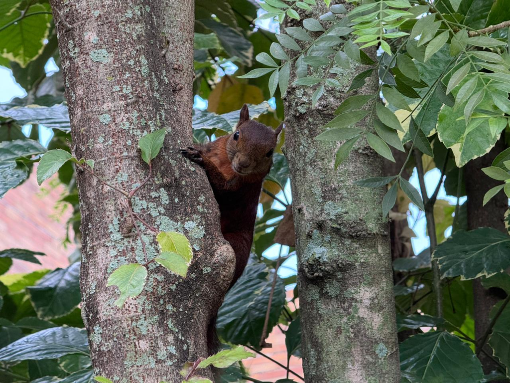

Ardilla en la PUJ.jpeg

Las ardillas rojas no solo añaden un toque de diversión a los bosques urbanos de la ciudad, sino que también juegan un papel crucial en el equilibrio del ecosistema local. Estos mamíferos son dispersores de grandes cantidades de semillas, y de esporas de hongos y flores. Así contribuyen con la forestación y el transporte de plantas y alimento a otras regiones de su hábitat. También son una importante fuente de proteína para reptiles, aves y otros mamíferos. Sin embargo, cuando su población se eleva en exceso, las ardillas rojas pueden provocar daños a cultivos y hasta ser consideradas como una plaga.

## Objetivos

### Objetivo general

Diseñar e implementar computacionalmente un modelo matemático que permita estimar la población de ardillas rojas en varias zonas verdes de Santiago de Cali, para varios grupos de edades, a partir de información inicial acerca de su comportamiento reproductivo, hábitos alimenticios y proyección de vida.

### Objetivos específicos

- Conocer las representaciones de algunas estructuras numéricas e instrucciones en el lenguaje de programación Python.
- Operar correctamente con estructuras numéricas apoyándose en pequeños fragmentos de código.
- Usar correctamente las operaciones con números representados en notación científica y fraccionarios en un contexto determinado.
- Explorar las propiedades de los números y sus operaciones con la ayuda de experimentos computacionales.
- Usar el lenguaje de programación Python como apoyo para solucionar las preguntas asociadas al reto planteado.

## Trabajando con Python

### Operaciones con números

El lenguaje de programación Python permite representar números y operarlos aritméticamente de manera sencilla. Por ejemplo, el siguiente fragmento de código imprime la suma, multiplicación y división de dos variables numéricas, `a` y `b`, cuyos valores iniciales son 5 y 3, respectivamente. La instrucción `print` se usa para mostrar el resultado de evaluar una expresión dada.

```python
a=5
b=3
print(a+b)
print(a*b)
print(a/b)
```

```
8
15
1.6666666666666667
```

El resultado de la ejecución del fragmento de código inicial se calcula al presionar el botón que aparece en la esquina superior izquierda de la caja que agrupa el código. A esta caja se le denomina **celda**. En el caso anterior, cada instrucción `print` en la celda genera una línea de respuesta.

Tal y como sucede al operar matemáticamente con números, en un lenguaje de programación como Python tampoco es permitido efectuar divisiones cuando el divisor es 0. Al tratar de efectuar una operación así, la ejecución de la instrucción correspondiente resulta en un error de ejecución.

```python
1/0
```

[output not shown]

En particular, la ejecución de la celda anterior indica que el error de ejecución es de tipo `ZeroDivisionError` y proporciona información adicional de la instrucción que generó dicho error, como la ubicación de la línea de código que origina el error (en este caso la línea 1) y la expresión que concretamente genera el error (en este caso, dividir 1 entre 0).

Con la ayuda de Python, también es posible realizar otras operaciones como la potenciación. Para ello se usa el operador `**`. En la siguiente celda se encuentra un fragmento de código que muestra la evaluación de $2^3$:

```python
print(2**3)
```

[output not shown]

Python soporta una gran cantidad de operaciones aritméticas de manera directa. Adicionalmente, ofrece una librería que agrupa otra cantidad significativa de operaciones aritméticas o con números, incluyendo operaciones trigonométricas. Esta librería es denominada `math`.

Como se muestra en la siguiente celda, se pueden usar las operaciones básicas y las que suministra `math` indistintamente en una misma celda de código. Para usar las operaciones suministradas por esta liberería, se debe anteponer el prefijo `math.` al nombre de la operación.

```python
import math                     # importar librería math
a=4
b=-4
print(a**(1/2))                 # operación potencia
print(math.sqrt(a))             # operación raíz cuadrada desde math
print(abs(b))                   # operación valor absoluto
```

[output not shown]

Las dos primeras operaciones corresponden al cálculo de la raíz cuadrada: en la primera línea se calcula directamente usando la instrucción de exponenciación (y la identidad $\sqrt{4}=4^{\frac{1}{2}}$), mientras que en la segunda línea este valor se calcula usando la función `sqrt` de `math` específicamente implementada para ello. La tercera línea muestra el resultado de calcular el valor absoluto $|-4|$ de $-4$ sin usar la librería `math`.

### Notación científica

La notación científica es una forma compacta de representar números. Es especialmente útil cuando los números son muy grandes o muy pequeños.

En la notación científica un número se escribe como el producto de un número entre 1 y 9, y una potencia de 10. Por ejemplo, el número $3000000$ se puede escribir como $3 \times 10^6$ en notación científica. En Python, se usa la letra `e` para indicar la potencia de 10 que identifica al número. Por ejemplo, este número se escribiría como `3e6`, que es una representación compacta.

La siguiente celda contiene ejemplos de algunos números escritos en notación científica usando el lenguaje de programación Python.

```python
a=3000000
print(a)
print('{0:1e}'.format(a))
print('{0:1.2e}'.format(a))
```

```
3000000
3.000000e+06
3.00e+06
```

Los tres casos muestran representaciones de $3 \times 10^6$. En el primer caso se despliega este número sin ningún formato específico y, en consecuencia, Python usa la representación por defecto para números sin decimales. En la segunda línea se usa un formato específico con un dígito de unidad y seis cifras decimales (la cantidad de ceros después del punto de unidades), mientras que en la tercera se usan un dígito de unidad y dos cifras decimales.

#### Suma y resta

Para sumar o restar dos números en notación científica, **matemáticamente** primero se escriben los números en la misma potencia de 10 y luego se operan las unidades. Por ejemplo, si se desea sumar $3 \times 10^6$ y $2 \times 10^5$, primero se escriben los números en la misma potencia de 10 y luego se suman los números, por último se ajusta al formato de notación científica. En Python, esto se puede hacer directamente, como muestra la celda siguiente.

```python
a=3e6
b=2e5
print(a+b)
print('{0:1.2e}'.format(a+b))       # Usando formato de notación científica
```

[output not shown]

#### Multiplicación y división

Para multiplicar o dividir dos números en notación científica, **matemáticamente** primero se multiplican o dividen los *números* entre 1 y 9, y luego se suman o restan las potencias de 10. Por ejemplo, si queremos multiplicar $3 \times 10^6$ y $2 \times 10^5$, primero se multiplican $3$ y $2$, y luego se suman $6$ y $5$ al ser sus potencias de $10$, respectivamente. Al igual que con la suma y la resta, estas operaciones pueden hacerse directamente en Python.

```python
a=3e6
b=2e5
print(a*b)
print('{0:1.2e}'.format(a*b))       # Usando formato de notación científica
```

[output not shown]

### Números racionales

Existen limitaciones al representar números en un computador, puesto que sólo es posible construir representaciones exactas de un conjunto **finito de números**, y no de todos los números reales. Esto ocurre en cualquier lenguaje de programación, incluyendo Python. Por ello es importante tener cuidado cuando se realizan operaciones con números decimales, ya que en la inmensa mayoría de los casos no se obtiene una representación exacta del número deseado, lo cual, genera errores de precisión, que se pueden acumular en la medida que se hagan muchas operaciones.

En los lenguajes de programación, como Python, se usan números decimales para hacer operaciones aritméticas. Sin embargo, en ocasiones es deseable trabajar con números racionales, es decir, números de la forma $\frac{a}{b}$ con $a$ y $b$ enteros y $b$ diferente de cero. Por ejemplo, el número $\frac{1}{3}$, se puede representar en Python, con la librería `fractions` que permite trabajar con este tipo de números.

El siguiente fragmento de código, que no es necesario que entienda, define dos funciones que permiten sumar y multiplicar fracciones usando `fractions`, y detectar cuándo se está tratando de definir u operar una fracción con denominador $0$ (lo cual no es permitido).

#### Suma y resta

La siguiente celda permite calcular la suma
$$\frac{a}{b} + \frac{c}{d}$$
cuando, de manera interactiva, se escogen los valores de $a,b,c$ y $d$.

```python
import requests
# URL del archivo
url = "https://raw.githubusercontent.com/abelalv/PUJ_MMAF/main/libreria1.py"
# Descargar el archivo
response = requests.get(url)
with open('libreria1.py', 'w') as file:
    file.write(response.text)
```

```python
import libreria1 as li
from IPython.display import display
import ipywidgets as widgets
# crear un widget interactivo para la gráfica
exp_widget = widgets.interactive(li.sumar_fracciones, a=li.a_slider, b=li.b_slider, c=li.c_slider, d=li.d_slider)

# Mostrar el widget
display(exp_widget)
```

#### Multiplicación y división

La siguiente celda permite calcular el producto
$$\frac{a}{b}\times \frac{c}{d}$$
cuando, de manera interactiva, se escogen los valores de $a,b,c$ y $d$.

```python
import libreria1 as li
from IPython.display import display
import ipywidgets as widgets

# Crear un widget interactivo para la gráfica
exp_widget = widgets.interactive(li.multiplicar_fracciones, a=li.a_slider, b=li.b_slider, c=li.c_slider,d=li.d_slider)

# Mostrar el widget
display(exp_widget)
```

### Ejercicios de apropiación y aplicación

1. Determine los siguientes valores:
- La parte entera de $3.14$.
- El techo de $3.14$.
- El piso de $3.14$.
2. Realice las siguientes operaciones con números en notación científica:
- $(5 \times 10^6) + (4 \times 10^5)$.
- $(5 \times 10^6) - (4 \times 10^5)$.
- $(5 \times 10^6) \times (4 \times 10^5)$.
- $(5 \times 10^6) / (4 \times 10^5)$.
3. Realice las siguientes operaciones con números racionales:
- $\dfrac{3}{4} + \dfrac{2}{3}$.
- $\dfrac{1}{5} - \dfrac{2}{3}$.
- $\dfrac{3}{4} \times \dfrac{2}{3}$.
- $\dfrac{3}{4} \div \dfrac{2}{3}$.

## Conexión con el reto

### Dinámica de alimentación de las ardillas rojas

Biólogos de la Pontificia Universidad Javeriana han estudiado la población de ardillas rojas en varias zonas verdes de Santiago de Cali, y han logrado inferir su distribución y hábitos alimenticios. Durante un año de análisis, han registrado una población total de $1.237 \times 10^4$ ardillas. Estos biólogos también han logrado clasificar las ardillas en tres grupos principales según sus hábitos alimenticios:

- Ardillas que se alimentan principalmente de frutas y nueces.
- Ardillas que se alimentan principalmente de frutas y nueces, con preferencia por los frutos de las palmas.
- Ardillas que se alimentan de una dieta variada, incluyendo frutas, nueces y larvas de insectos.

Las observaciones han revelado las siguientes proporciones en la población de ardillas:

| Tipo de consumo de la Ardilla | Proporción | Consumo Diario (g) |
| --- | --- | --- |
| Frutas | 35% | $3.1 \times 10^2$ |
| Semillas y Nueces | 45% | $2.5 \times 10^2$ |
| Dieta Variada | 20% | $2.8 \times 10^2$ |

Con base en la información obtenida por los biólogos de la Universidad acerca de las ardillas en las zonas verdes bajo estudio, a continuación se formulan preguntas que ayudarán a entender y aumentar el grado de familiaridad con la dinámica alimentaria de las ardillas. La intención es que se apoye en el contenido expuesto y en celdas de código Python para responder estas preguntas.

1. ¿Cuántas ardillas se alimentan principalmente de frutas? Exprese la respuesta en notación científica con exactamente 2 cifras decimales.

**Respuesta.** El 35% de la población de las ardillas que alimenta principalmente de frutas. Es decir, $0.35$ de $1.237 \times 10^4$ ardillas se alimentan principalmente de frutas. En total, son $4330$ ardillas, aproximadamente, las que cumplen con la condición dada.

```python
print('{0:.2e}'.format(0.35*1.237e4))
```

```
4.33e+03
```

2. ¿Cuántas ardillas se alimentan principalmente de semillas y nueces? Exprese la respuesta en notación científica con exactamente 2 cifras decimales.
3. ¿Cuántas ardillas tienen una dieta variada? Exprese la respuesta en notación científica con exactamente 2 cifras decimales y también como un número fraccionario.
4. ¿Cuál es el consumo diario total de comida para cada grupo de ardillas? Exprese las cantidades en notación científica con exactamente 3 cifras decimales y también como un número fraccionario.

## Reto 1

### Dinámica de reproducción de las ardillas

También se está investigando el comportamiento de la población de ardillas rojas. Se ha inferido la siguiente información sobre la población actual de ardillas en las zonas bajo estudio:

- Ardillas adultas (1 año o más): 6810.
- Ardillas juveniles (26 a 52 semanas): 2470.
- Ardillas crías (0 a 26 semanas): 3090.

Adicionalmente, se ha encontrado la siguiente información sobre la especie:

- **Proporción de género:** la proporción de machos a hembras es de uno a uno en todas las clases de edades (es decir, hay igual número de machos y hembras en cada grupo de edad).
- **Ciclo reproductivo:** un ciclo reproductivo dura 26 semanas. Cada hembra adulta tiene dos crías por ciclo reproductivo. **Nota las crías que sobreviven se cuentan al inicio del ciclo se cuentan a partir de las hembras que sobrevivieron en el ciclo anterior.**
- **Supervivencia en el siguiente ciclo reproductivo:**
- De las 3090 crías, 618 sobrevivieron y pasan a ser juveniles.
- De las 2470 ardillas juveniles, 1729 sobrevivieron y pasan a ser adultas.
- De las 6810 ardillas adultas, 5448 sobrevivieron.

Con base en la información anterior y las herramientas computacionales brindadas por el lenguaje de programación Python, responda las siguientes preguntas.

1. ¿Cuál es el porcentaje de supervivencia en cada grupo de edad?

$$\text{Porcentaje de supervivencia} = \left( \frac{\text{Número de sobrevivientes}}{\text{Población inicial}} \right) \times 100$$

De esta forma encontramos que el porcentaje de supervivencia en cada grupo de edad es:

- En el grupo de crías: $20\%$.
- En el grupo de juveniles: $70\%$.
- En el grupo de adultos: $80\%$.
2. ¿Cuál es la población total de ardillas después del primer ciclo reproductivo?

3. ¿Cuál es la población total de ardillas después de cinco ciclos reproductivos?

# ciclo 1

Total 13243

# Ciclo 2

- Juveniles sobrevivientes: $618 \times \frac{70}{100} = 432.6 \approx 433$
- Adultas sobrevivientes: $1729 \times \frac{80}{100} = 1383.2 \approx 1383$
- Total: $1362 + 433 + 1383 + 5448 = 8,626$

# ciclo 3

Nuevas crías: $\frac{1383}{2} \times 2 = 1383$ + Crías sobrevivientes: $5448 \times \frac{20}{100} = 1089.6 \approx 1090$

- Juveniles sobrevivientes: $1362 \times \frac{70}{100} = 953.4 \approx 953$
- Adultas sobrevivientes: $433 \times \frac{80}{100} = 346.4 \approx 346$
- Total: $1090 + 953 + 346 + 1383 = 3772$

# ciclo 4

# ciclo 5